# CS 1675 Spring 2022: Homework 11

Assigned April 14, 2022; Due: April 21, 2022

Binghan Zheng

Submission time: April 21, 2022 at 11:00PM EST

#### Collaborators

Clark

## Overview

This is an applied assignment focused on training binary classifiers. You will try out several models discussed in lecture this semester including: logistic regression, elastic net, neural network, random forest, and gradient boosted trees. You will tune the models using `caret` and then make predictions to study the trends.

**IMPORTANT**: code chunks are created for you. Each code chunk has `eval=FALSE` set in the chunk options. You **MUST** change it to be `eval=TRUE` in order for the code chunks to be evaluated when rendering the document.

You are allowed to add as many code chunks as you see fit to answer the questions.

## Load packages

This assignment will use packages from the `tidyverse` suite and `caret`. The models that you will train require their own set of packages. The `caret::train()` function will prompt you to download the necessary packages. Thus, when you run those code portions please look at the R Console for the prompt that you must respond to. The assignment also requires the `mlbench`, `corrplot`, and `yardstick` packages.

The `tidyverse` and `caret` packages are loaded for you below. If you do not have `caret` please download and install now.

```r
library(tidyverse)
library(caret)
```

## Read in data

You will work with the `Sonar` data set in this assignment. The Sonar data set has become a classic data set for training binary classifiers. The data are available in the `mlbench` package. If you do not have `mlbench` please download and install it before proceeding.

The code chunk below reads in the `Sonar` data for you and displays the number of rows and columns to screen.

```r
data("Sonar", package = 'mlbench')

Sonar %>% dim()
```

```
## [1] 208  61
```

As you can see above this a fairly high dimensional problem, especially relative to the number of observations. The input features of the Sonar data set correspond to features extracted from sonar signals (hence the data name). Your task is to classify the binary outcome, `Class`, as either `"M"` for metal or `"R"` for rock.

## Problem 01

We will perform a short exploration of the features in this data set. First, let’s look at summary statistics for each of the input variables. The code chunk below creates a long-format dataset for you by gathering the input features into a single column via the `pivot_longer()` function. The input variable ID is extracted for you and assigned to the `input_id` column.

```r
lf_sonar <- Sonar %>%
  tibble::rowid_to_column("obs_id") %>%
  pivot_longer(!c("obs_id", "Class")) %>%
  mutate(input_id = as.numeric(stringr::str_extract(name, "\\d+")))

lf_sonar %>% glimpse()
```

```
## Rows: 12,480
## Columns: 5
## $ obs_id   <int> 1, 1, 1, 1, 1, 1, 1, 1, 1, 1, 1, 1, 1, 1, 1, 1, 1, 1, 1, 1, 1~
## $ Class    <fct> R, R, R, R, R, R, R, R, R, R, R, R, R, R, R, R, R, R, R, R, R~
## $ name     <chr> "V1", "V2", "V3", "V4", "V5", "V6", "V7", "V8", "V9", "V10", ~
## $ value    <dbl> 0.0200, 0.0371, 0.0428, 0.0207, 0.0954, 0.0986, 0.1539, 0.160~
## $ input_id <dbl> 1, 2, 3, 4, 5, 6, 7, 8, 9, 10, 11, 12, 13, 14, 15, 16, 17, 18~
```

The above long-format data set will help with a few of the visualizations we will use to explore the data.

### 1a)

You will start out by visualizing the summary statistics for each input feature via boxplots.

**Pipe the `lf_sonar` object into `ggplot()`. Map the `x` aesthetic to `input_id` and map the `y` aesthetic to `value`. Include a `geom_boxplot()` geom where the `group` aesthetic is mapped to `input_id`.**

**Describe the bounds on the input features. Do the inputs have very different scales?**

#### SOLUTION

Yes, the distribution of the input values is mostly concentrated in the middle and the tails have more concise distributions.

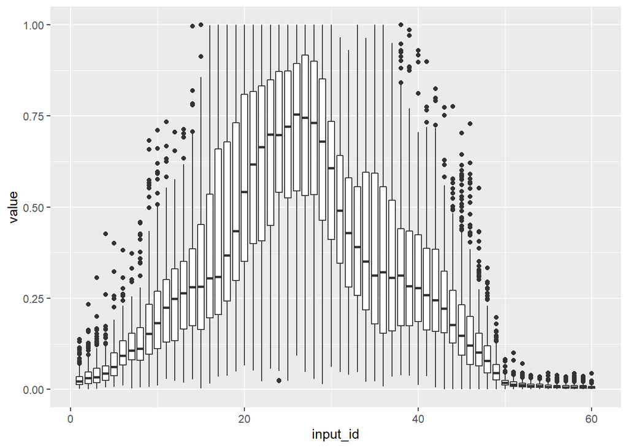

```r
###
lf_sonar %>% ggplot() +
  geom_boxplot(aes(x = input_id, y = value, group = input_id))
```

What do you think?

### 1b)

Boxplots are useful for visualizing summary statistics. However, we are unable to visualize the shape of the distributions with boxplots. In this problem, you will use frequency polygons (a type of histogram) to visualize the distributional shapes for each input.

**Pipe the `lf_sonar` object into `ggplot()` and map the `x` aesthetic to `value`. Include a `geom_freqpoly()` geom with the `group` aesthetic mapped to `input_id`. Set the number bins equal to 21 by setting `bins=21` in the `geom_freqpoly()` call. Break up your visualizations by groups of 5 inputs by including `facet_wrap()` where the facet variable is:**

`cut(input_id, breaks=seq(1, 60, length.out = 12), include.lowest = TRUE)`

**Set the `scales` argument in `facet_wrap()` to be `scales='free_y'` so it’s easier to see the shapes for each group of inputs.**

**NOTE**: If your facet variable is created correctly, the facet strips will show you the input IDs associated with each facet. For example, the first facet will display `[1,6.36]` and the last facet will be display `(54.6,60]`. Although decimal values are shown, `input_id` contains whole number integers. The decimals are fine for now. It’s just a simple way to break up the variables.

#### SOLUTION

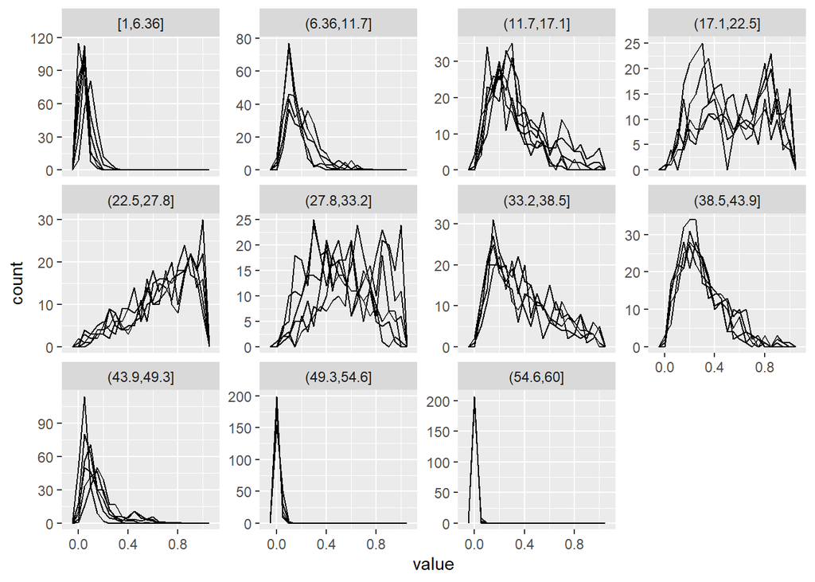

```r
lf_sonar %>% ggplot(aes(x = value)) +
  geom_freqpoly(aes(group = input_id), bins = 21) +
  facet_wrap(~ cut(input_id, breaks=seq(1, 60, length.out = 12), include.lowest = TRUE), scales = 'free_y')
```

### 1c)

**Based on your visualizations, do you think the input features should be pre-processed? If so, what preprocessing technique should be considered?**

#### SOLUTION

Yes, the log transformation pre-processing would be appropriate as it would adjust the skew.

### 1d)

Let’s now consider the correlation structure of the inputs. Use the `corrplot::corrplot()` function to create the correlation plot matrix associated with all 60 input features. However, rather than using the default ordering, instruct `corrplot()` to reorder inputs such that all highly correlated inputs are grouped together. `corrplot()` will use a hierarchical clustering method and group all inputs for you.

**Pipe the original wide-format `Sonar` data into the `dplyr::select()` function and select all except the `Class` variable. Pipe the result into `cor()` and pipe the result into `corrplot::corrplot()`. Set the `method` argument equal to `"square"`, the `order` argument equal to `"hclust"`, and the ‘hclust.method`equal to`’ward.D2’`.**

**Is there a correlation structure between the inputs?**

The middle and lower half of the visualizations exhibit notable clusters even if there is little correlation overall.

#### SOLUTION

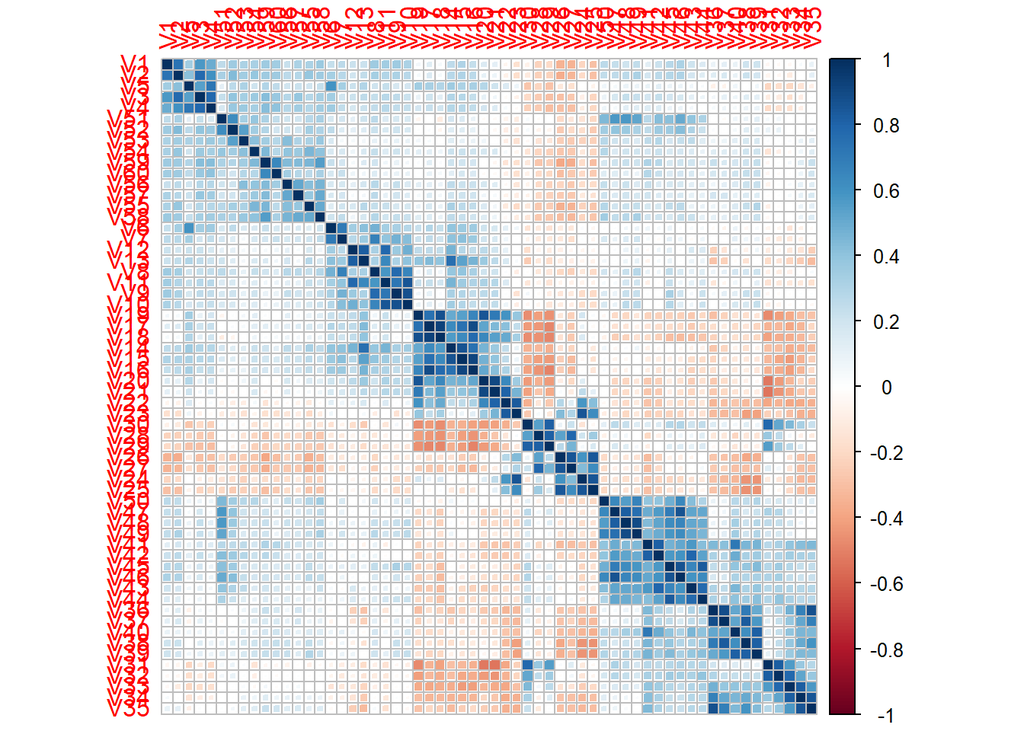

```r
Sonar %>% select(-Class) %>% cor() %>% corrplot::corrplot(method = "square", order = "hclust", hclust.method = 'ward.D2')
```

### 1e)

The last visualization you will make as part of a quick exploratry data analysis (EDA) is to count the number of observations per level of the binary outcome `Class`. This is important to do before training any binary classification model, in order to check if there is a severe imbalance between either of the two classes.

**Pipe the `Sonar` data set into `ggplot()` and set the `x` aesthetic equal to `Class`. Use the `goem_bar()` function to show a bar chart giving the number of observations per level of `Class`.**

**Do you think we should be concerned about an imbalance between the `"M"` and `"R"` levels?**

#### SOLUTION

Since the proportion of event to nonevent is similar to M to R, we shouldn’t be concerned.

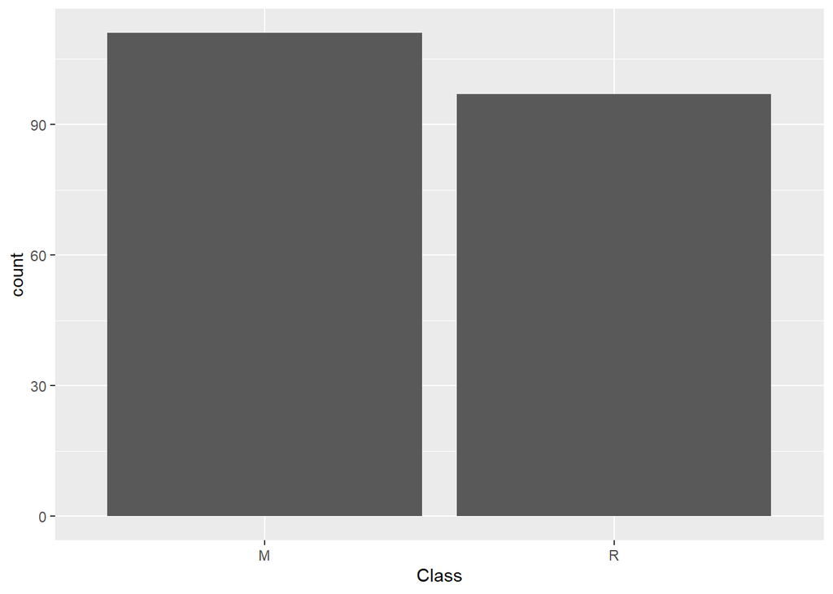

```r
Sonar %>% ggplot(mapping = aes(x = Class)) +
  geom_bar()
```

What do you think?

## Problem 02

You will train several models to predict the binary outcome `Class`. You will try logistic regression, logistic regression with the elastic net penalty, and more complex non-linear methods. As stated at the beginning of the assignment, you will use `caret` for the training, tuning, and model selection process.

### 2a)

You must start, by specifying the resampling scheme and the primary performance metric. You will use 5-fold cross-validation, and you will compare models by maximizing the Area Under the ROC Curve (ROC AUC). You must specify the metric to be `"ROC"` in order to tell `caret` to maximize the AUC (the naming convention is a little confusing). The code chunk below is started for you, and provides some arguments to the `trainControl()` function which are required in order to use `"ROC"` as the primary performance metric.

**Complete the code chunk below. Finish the `trainControl()` call such that you will use 5-fold cross-validation. Assign `"ROC"` to the `metric_sonar` variable.**

#### SOLUTION

```r
ctrl_k05_roc <- trainControl(method = "repeatedcv",
                             number = 5,
                             repeats = 3,
                             summaryFunction = twoClassSummary,
                             classProbs = TRUE,
                             savePredictions = TRUE)

metric_sonar <- 'ROC'
```

### 2b)

You will start with a logistic regression model using linear additive terms for all input features. Remember that the short cut operator `.` denotes using “everything in the data set”. So you do not have to type out all 60 input variable names in the formula interface. The formula requires the name of the response variable, and so remember that the outcome is the `Class` variable, not `y` as in other assignments and lecture examples.

You will use the `train()` function to train the logistic regression model. You must specify the formula interface, and specify the `data` to be `Sonar`. To use the base `R` logistic regression method in `glm()`, you must set the `method` argument equal to `"glm"`. You must also specify the `metric` argument to be the `metric_sonar` variable you assigned Problem 2a) in order for `caret` to identify the best model by maximizing the area under the ROC curve. You must also specify the `trControl` argument to be the `ctrl_k05_roc`.

You must set the `preProcess` argument based on your answer to Problem 1c). If you do not feel you need to pre-process the inputs then you do not need to include the `preProcess` argument. If you feel you should, then you should set the `preProcess` argument to your desired pre-processing operation.

**Specify the arguments to the `train()` function in order to train a logistic regression model for the `Sonar` data set with 5-fold cross-validation and calculate the area under the ROC curve.**

**The area under the ROC curve is referred to by `caret` as `"ROC"`. The cross-validation averaged performance merics are printed to the screen for you. What is the area under the ROC curve for your logistic regression model?**

*HINT*: You can ignore warnings displayed during the training of the logistic regression model.

#### SOLUTION

ROC AUC: 0.7477375

```r
set.seed(4321)
fit_glm_sonar <- train(Class ~ .,
                       preProcess = c("center", "scale"),
                       data = Sonar,
                       method = "glm",
                       metric = metric_sonar,
                       trControl = ctrl_k05_roc)
```

```
## Warning: glm.fit: algorithm did not converge
```

```r
fit_glm_sonar
```

```
## Generalized Linear Model
##
## 208 samples
##  60 predictor
##   2 classes: 'M', 'R'
##
## Pre-processing: centered (60), scaled (60)
## Resampling: Cross-Validated (5 fold, repeated 3 times)
## Summary of sample sizes: 166, 167, 165, 167, 167, 166, ...
## Resampling results:
##
##   ROC        Sens       Spec
##   0.7477375  0.7604743  0.6985965
```

### 2c)

Since there are relatively few observations based on the number of inputs in `Sonar`, let’s apply regularization to the linear additive features. Because you are using linear additive terms you may use the shortcut operator `.` in the formula. The `glmnet` package will fit a logistic regression model with the elastic net penalty term. You need to set `method` to `"glmnet"`. The remaining arguments should be consistent to your arguments used in Problem 2b).

**Train an elastic net model and tune the hyperparameters with 5-fold cross-validation to maximize the area under the ROC curve. You can use the default tuning grid from `caret` and so you do NOT need to set the `tuneGrid` argument.**

**Should you consider applying preprocessing with the regularized model?**

Yes preprocessing with the regularized model will penalize the large coefficients. This would affect the test set predictions, since it may lead to overfitting if we do not preprocess the training set.

**Based on the training results, does the elastic net model favor LASSO or RIDGE more?**

#### SOLUTION

```r
set.seed(4321)
fit_glmnet_sonar <- train(Class ~ .,
                       preProcess = c("center", "scale"),
                       data = Sonar,
                       method = "glmnet",
                       metric = metric_sonar,
                       trControl = ctrl_k05_roc)

fit_glmnet_sonar
```

```
## glmnet
##
## 208 samples
##  60 predictor
##   2 classes: 'M', 'R'
##
## Pre-processing: centered (60), scaled (60)
## Resampling: Cross-Validated (5 fold, repeated 3 times)
## Summary of sample sizes: 166, 167, 165, 167, 167, 166, ...
## Resampling results across tuning parameters:
##
##   alpha  lambda        ROC        Sens       Spec
##   0.10   0.0004318733  0.8388274  0.7905138  0.7354386
##   0.10   0.0043187332  0.8532609  0.7967062  0.7491228
##   0.10   0.0431873324  0.8565013  0.7911726  0.7421053
##   0.55   0.0004318733  0.8368549  0.7814229  0.7189474
##   0.55   0.0043187332  0.8543534  0.8057971  0.7254386
##   0.55   0.0431873324  0.8405596  0.7791831  0.7178947
##   1.00   0.0004318733  0.8292736  0.7722003  0.7261404
##   1.00   0.0043187332  0.8478275  0.7969697  0.7115789
##   1.00   0.0431873324  0.8318761  0.7761528  0.7280702
##
## ROC was used to select the optimal model using the largest value.
## The final values used for the model were alpha = 0.1 and lambda = 0.04318733.
```

### 2d)

Let’s now try a neural network model with the `nnet` package. You must specify the `method` argument equal to `"nnet"`. Non-linear models will attempt to find non-linear relationships between the inputs and the response even if the simple formula `Class ~ .` is provided. Thus, you do not need to type in all input names to the formula object. The `.` shortcut of “everything else” is instructing the formula to use “everything else” as an input. You can use the default tuning grid, and so you do not need to specify the `tuneGrid` argument to `train()`.

**Train a neural network binary classifier using the `"nnet"` package with `caret`. Does the neural network model achieve a higher area under the ROC curve compared to the elastic net model?**

**Should you preprocess the inputs before training the neural network?**

**NOTE**: The `trace` argument is set to `FALSE` for you already. Otherwise the iteration results are printed. We are focused on the model performance results in this assignment, and so we do not need the iteration results printed to the screen.

#### SOLUTION

The neutal network has a higher ROC

preprocessing is recommended to neural networks since the differences in the scales across inputs makes models more difficult to create and may result in larger weight values.

```r
set.seed(4321)
fit_nnet_sonar <- train(Class ~ .,
                        preProcess = c("center", "scale"),
                        data = Sonar,
                        method = "nnet",
                        metric = metric_sonar,
                        trControl = ctrl_k05_roc,
                        trace = FALSE)

fit_nnet_sonar
```

```
## Neural Network
##
## 208 samples
##  60 predictor
##   2 classes: 'M', 'R'
##
## Pre-processing: centered (60), scaled (60)
## Resampling: Cross-Validated (5 fold, repeated 3 times)
## Summary of sample sizes: 166, 167, 165, 167, 167, 166, ...
## Resampling results across tuning parameters:
##
##   size  decay  ROC        Sens       Spec
##   1     0e+00  0.7765250  0.7673254  0.7152632
##   1     1e-04  0.8113822  0.7725955  0.7494737
##   1     1e-01  0.8288610  0.7761528  0.7152632
##   3     0e+00  0.8401862  0.7932806  0.7603509
##   3     1e-04  0.8504155  0.8142292  0.7317544
##   3     1e-01  0.8599553  0.8179183  0.7321053
##   5     0e+00  0.8159228  0.7814229  0.7628070
##   5     1e-04  0.8393293  0.8143610  0.7598246
##   5     1e-01  0.8899795  0.8478261  0.7664912
##
## ROC was used to select the optimal model using the largest value.
## The final values used for the model were size = 5 and decay = 0.1.
```

### 2e)

Neural networks are challenging to interpret. Several methods have been devised to try and provide interpretibility by providing ways to rank the input variable importance using the weights associated with all hidden units and the output layer.

**You may use the default `caret` provided method for ranking variable importance for the neural network. Plot the variable importances using the default plot method. Then plot the variable importances a second time but set the `top` argument equal to 20 in the `plot()` method call. This will limit to the plot to just the top 20 ranked inputs.**

**What are the top 4 ranked input features as viewed by the neural network?**

#### SOLUTION

The top 4 ranked input features V26, V8, V31, and V50.

Plot all variable importances.

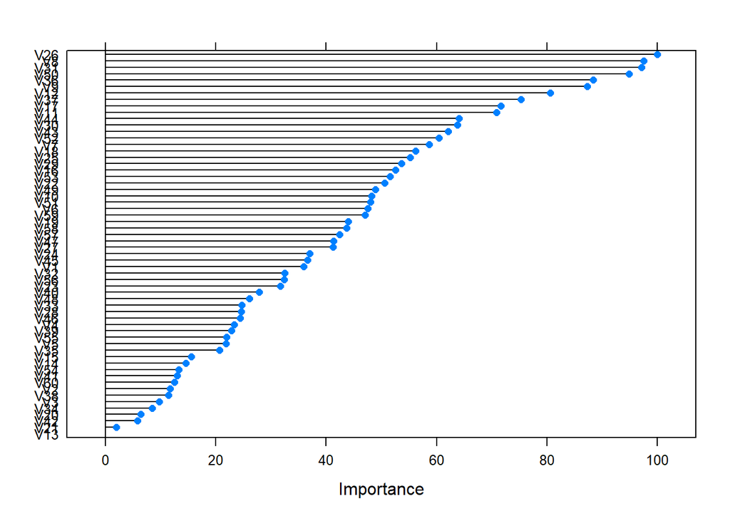

```r
###
plot(varImp(fit_nnet_sonar))
```

Plot just the top 20 variable importances.

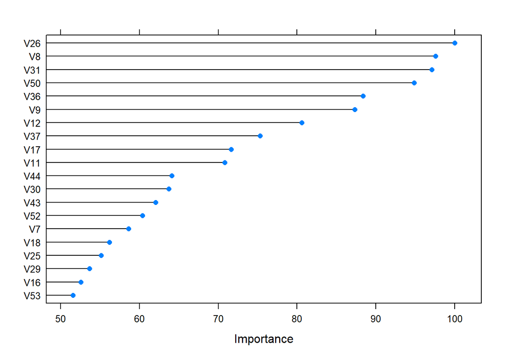

```r
###
plot(varImp(fit_nnet_sonar), top=20)
```

What do you think?

### 2f)

You will use predictions to help gain further understanding of the influence of the top ranked input features. Two functions are provided for you below which you will use to construct an input grid to make predictions. The first function, `make_test_input_list()` is defined in the code chunk below. The first argument to `make_test_input_list()` is a variable name. The second input argument, `top_4_inputs`, is a character vector. The second input argument will hold the names associated with the top 4 ranked input features. The last input argument, `all_data`, is a tibble or data.frame. The last input argument is intended to hold the training data set.

The `make_test_input_list()` function therefore creates a grid of 25 evenly spaced points between the training set min and max bounds for the top 2 ranked inputs. The third and fourth ranked inputs are given 5 unique values, based on specific quantiles of the training set. All other inputs are set to constant values equal to their training set medians.

```r
make_test_input_list <- function(var_name, top_4_inputs, all_data)
{
  xvar <- all_data %>% select(var_name) %>% pull()

  if (var_name %in% top_4_inputs[1:2]){
    # use 25 unique values between the min/max values
    xgrid <- seq(min(xvar), max(xvar), length.out = 25)
  } else if (var_name %in% top_4_inputs[3:4]){
    # specify quantiles to use
    xgrid <- quantile(xvar, probs = c(0.05, 0.25, 0.5, 0.75, 0.95), na.rm = TRUE)
    xgrid <- as.vector(xgrid)
  } else {
    # set to their median values
    xgrid <- median(xvar, na.rm = TRUE)
  }

  return(xgrid)
}
```

The second function, `make_test_input_grid()`, is a wrapper function. It iteratively applies the `make_test_input_list()` function to all inputs and then uses the `expand.grid()` function to create full factorial grid based on the list of unique input values.

```r
make_test_input_grid <- function(all_input_names, top_4_inputs, all_data)
{
  test_list <- purrr::map(all_input_names,
                          make_test_input_list,
                          top_4_inputs = top_4_inputs,
                          all_data = all_data)

  expand.grid(test_list,
              KEEP.OUT.ATTRS = FALSE,
              stringsAsFactors = FALSE) %>%
    purrr::set_names(all_input_names)
}
```

**You will use the `make_test_input_grid()` function to create a grid of input values based on the top 4 ranked inputs, as viewed by your tuned neural network model.**

**Complete the code chunk below by creating two vectors. The first, `my_input_names`, is a regular vector for the names of the input variables in the `Sonar` data set. The second, `my_top_ranked_inputs`, is a regular vector for the names of the top 4 ranked inputs based on your neural network model.**

**Call the `make_test_input_grid()` function and assign the result to `viz_input_grid`. Display the number of rows and columns in `viz_input_grid` to the screen.**

#### SOLUTION

Add as many code chunk as you feel necessary to complete this problem.

```r
###
top_4_inputs <- c("V26", "V8", "V31", "V50")
variable_names <- names(Sonar)
variable_names <- variable_names[1:60]

viz_input_grid <- make_test_input_grid(variable_names, top_4_inputs, Sonar)
```

```
## Note: Using an external vector in selections is ambiguous.
## i Use `all_of(var_name)` instead of `var_name` to silence this message.
## i See <https://tidyselect.r-lib.org/reference/faq-external-vector.html>.
```

```r
dim(viz_input_grid)
```

```
## [1] 15625    60
```

## Problem 03

We now have everything necessary to make predictions and study behavior. We have a test or visualization grid and we have several models that we can use to consider the influence between the inputs and the response. Since we are working with a binary classification problem, we can view the response two ways. First, we can consider the classification. Second, we can visualize the predicted event probability.

### 3a)

We will first classify using the neural network model, and then visualize those classifications as a surface plot. Predictions are made with the `predict()` function. The first argument is the model object and the second argument is the data set we wish to make predictions with.

When we are working with binary classification models, the default result of the `predict()` function is the class assuming a 50% threshold value.

**Make classifications on the test visualization grid using the neural network model and assign the result to the `pred_class_nnet` object. Check the data type of `pred_class_nnet` and look at the first few classifications with the `head()` function.**

#### SOLUTION

```r
###
pred_class_nnet <- predict(fit_nnet_sonar, viz_input_grid)
pred_class_nnet %>% head()
```

```
## [1] M M M M M M
## Levels: M R
```

### 3b)

You will now visualize the classification surface based on your neural network model, over your defined test grid.

**Pipe `viz_input_grid` into a `mutate()` call and assign the `pred_class` variable equal to `pred_class_nnet`. Pipe the result into `ggplot()` where the `x` aesthetic is your top ranked input and the `y` aesthetic is your second ranked input. Use a `geom_raster()` geom to visualize the surface by mapping the `fill` aesthetic to `pred_class`. Include `facet_grid()` to break up the prediction surfaces based on the third and fourth ranked inputs by assigning the vertical facets to the 4th ranked input and the horizontal facets to the 3rd ranked input. Specify the fill by including the `scale_fill_brewer()` with the `palette` argument equal to `'Set1'`.**

#### SOLUTION

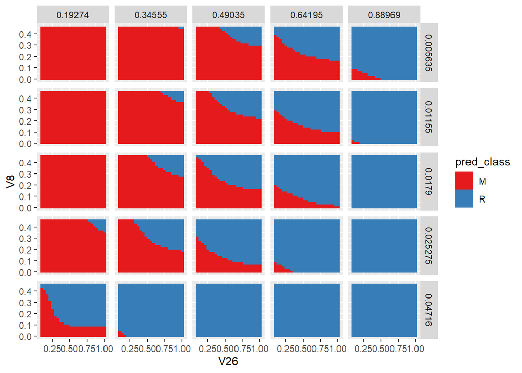

```r
###
viz_input_grid %>%
  mutate(pred_class = pred_class_nnet) %>%
  ggplot(aes(x = V26, y = V8)) +
  geom_raster(aes(fill = pred_class)) +
  facet_grid(V50 ~ V31) +
  scale_fill_brewer(palette = 'Set1')
```

### 3c)

You will now make classifications with the elastic net model on the test input grid.

**Predict the classifications with the elastic net model and assign the result to the `pred_class_enet` object.**

#### SOLUTION

```r
###
pred_class_enet <- predict(fit_glmnet_sonar, viz_input_grid)
```

### 3d)

Visualize the classification surface based on the elastic net model. Follow the same steps you used to make the surface with the neural network classifications.

**How do the visualizations of the classification surface compare with the neural network?**

#### SOLUTION

The classification surface of the elastic net model has horizontal lines instead of the step changes in the neural network model visualizations to indicate changes in important variables.

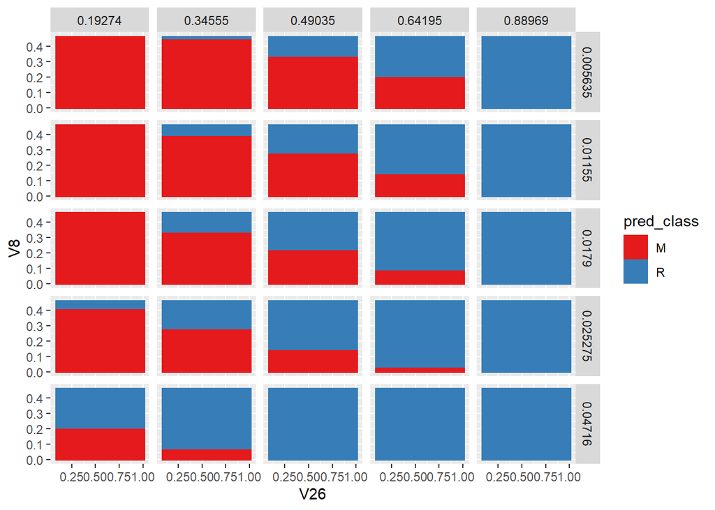

```r
viz_input_grid %>%
  mutate(pred_class = pred_class_enet) %>%
  ggplot(aes(x = V26, y = V8)) +
  geom_raster(aes(fill = pred_class)) +
  facet_grid(V50 ~ V31) +
  scale_fill_brewer(palette = 'Set1')
```

### 3e)

In addition to visualizing the classifications, we can also predict the class probabilities. This allows us to test out our classification threshold, if we would like. It also helps us understand if the predictions are near the threshold boundary.

Class probability predictions are also made with the `predict()` function. The first argument is still the model object, and the second argument is still the data set we wish to predict. We must include a third argument, `type`, which instructs the model the “type” of prediction to make. Setting the `type` argument equal to `'prob'` will return the class probabilities, instead of the classification label.

**Predict the class probabilities with the neural network model. Assign the result to the `pred_prob_nnet` object. Display the data type of `pred_prob_nnet` to the screen, as well as the result of the `head()` function applied to `pred_prob_nnet`. How do you know how to access the probability of the `'M'` class?**

#### SOLUTION

`mean(pred_prob_nnet$M)` yields mean probability of the `M` class

```r
pred_prob_nnet <- predict(fit_nnet_sonar, viz_input_grid, type = 'prob')
pred_prob_nnet %>% class()
```

```
## [1] "data.frame"
```

```r
pred_prob_nnet %>% head()
```

```
##           M           R
## 1 0.9948394 0.005160576
## 2 0.9945937 0.005406284
## 3 0.9942346 0.005765366
## 4 0.9937316 0.006268445
## 5 0.9930446 0.006955382
## 6 0.9921231 0.007876853
```

### 3f)

You will now visualize the predicted probability surface for the `M` class.

**Bind the columns of `viz_input_grid` to the columns in `pred_prob_nnet` using `bind_cols()`. Pipe the result into `ggplot()`. Map the `x` aesthetic to the top ranked input and the `y` aesthetic to the second ranked input. Use a `geom_raster()` geom to visualize the predicted `M` class surface by mapping the `fill` aesthetic to `M`. Include `facet_grid()` to break up the prediction surfaces based on the third and fourth ranked inputs by assigning the vertical facets to the 4th ranked input and the horizontal facets to the 3rd ranked input.**

**Specify the fill to be a diverging fill scale by including `scale_fill_gradient2()`. Set the `limits` argument to `c(0,1)`. Set the `low` argument to `'blue'`, the `high` argument to `'red'`, and the `mid` argument to `'white'`. Set the `midpoint` equal to `0.5`. These choices will give you high predicted probabilities that are bright red, with low predicted probabilities as bright blue and 50% probabilities as white. You will therefore be able to clearly see the 50% threshold decision boundary!**

#### SOLUTION

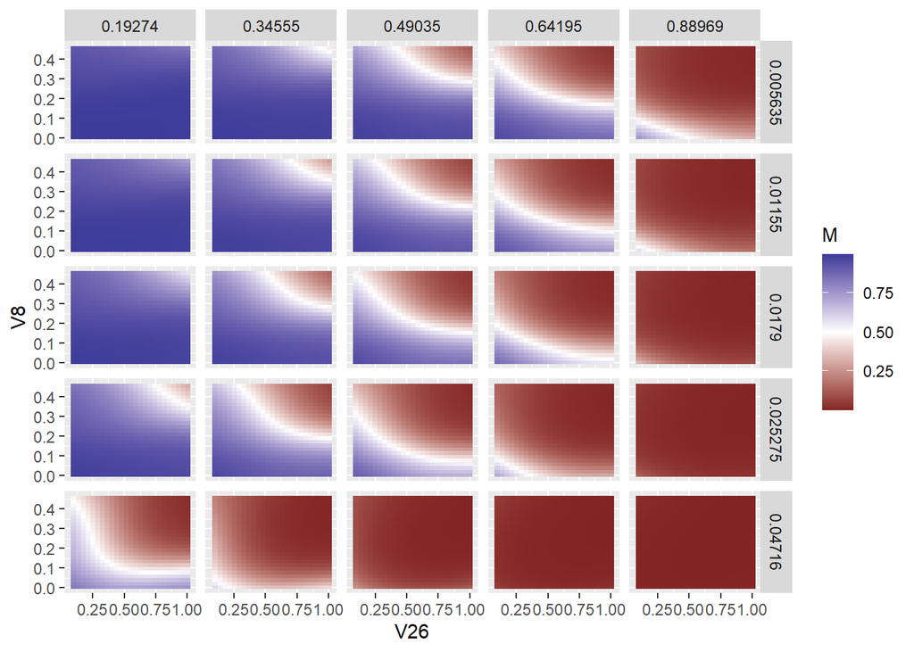

```r
bind_cols(pred_prob_nnet, viz_input_grid) %>%
  ggplot(aes(x = V26, y = V8)) +
  geom_raster(aes(fill = M)) +
  facet_grid(V50 ~ V31) +
  scale_fill_gradient2(mid = 'white', midpoint = 0.5)
```

## Problem 04

Let’s now try out tree-based methods and compare their performance with the elastic net and neural network models.

### 4a)

We could start with a standard decision tree with CART, but instead we will jump straight to the random forest. To train a random forest model, you must specify `method` equal to `"rf"`.

You can use the default tuning grid to the `mtry` tuning parameter.

**Do you need to consider preprocessing the inputs for a random forest?**

**Train a random forest binary classifier by setting the `method` argument equal to `"rf"`. The code chunk below includes the `importance=TRUE` argument for you.**

**What value of `mtry` was selected as the best, based on the cross-validation results? Why do you think that value was selected?**

#### SOLUTION

no, random forest does not require preprocessing

the best value for mtry was 2.

This is because the split value of 2 reduced the variance in the result of the predictive performance by injecting randomness into the treegrowing process. More trees are built and less splits were made, generating better results.

```r
set.seed(4321)
fit_rf_sonar <- train(Class ~ .,
                      data = Sonar,
                      method = "rf",
                      metric = metric_sonar,
                      trControl = ctrl_k05_roc,
                      importance = TRUE)

fit_rf_sonar
```

```
## Random Forest
##
## 208 samples
##  60 predictor
##   2 classes: 'M', 'R'
##
## No pre-processing
## Resampling: Cross-Validated (5 fold, repeated 3 times)
## Summary of sample sizes: 166, 167, 165, 167, 167, 166, ...
## Resampling results across tuning parameters:
##
##   mtry  ROC        Sens       Spec
##    2    0.9412945  0.9223979  0.7621053
##   31    0.9127918  0.8773386  0.7312281
##   60    0.8993022  0.8562582  0.7105263
##
## ROC was used to select the optimal model using the largest value.
## The final value used for the model was mtry = 2.
```

### 4b)

Now try training a boosted tree model with `xgboost`. You must set the `method` argument to `xgbTree` in order to tell `caret` to use the XGBoost implementation of the boosted tree algorithm. By default, many different tuning parameters are considered, so instead of printing out the results, the best tuning parameters are printed out for you. Then, the performance results are plotted for you.

**Train the XGBoost model with 5-fold cross-validation to maximize the area under the ROC curve.**

*NOTE*: The following code may take a few minutes to complete.

#### SOLUTION

Train the model.

```r
set.seed(4321)
fit_xgb_sonar <- train(Class ~ .,
                       data = Sonar,
                       method = 'xgbTree',
                       metric = metric_sonar,
                       trControl = ctrl_k05_roc,
                       verbosity = 0)
```

Print out the best tuning parameters.

```r
fit_xgb_sonar$bestTune
```

```
##    nrounds max_depth eta gamma colsample_bytree min_child_weight subsample
## 25      50         2 0.3     0              0.6                1         1
```

Plot the cross-validation results.

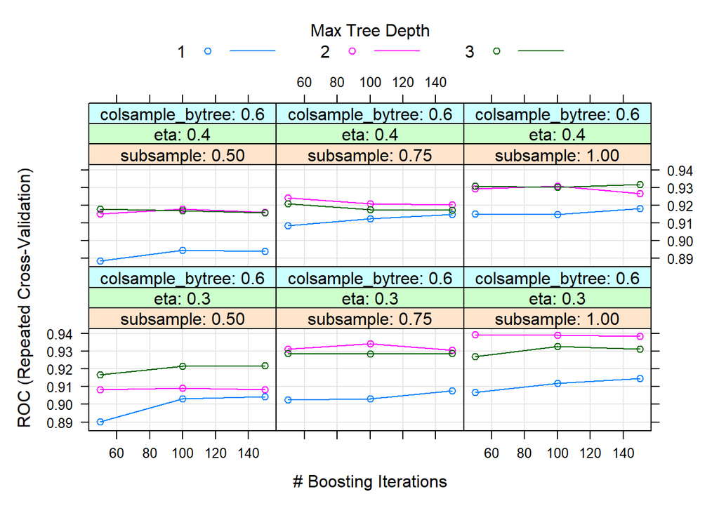

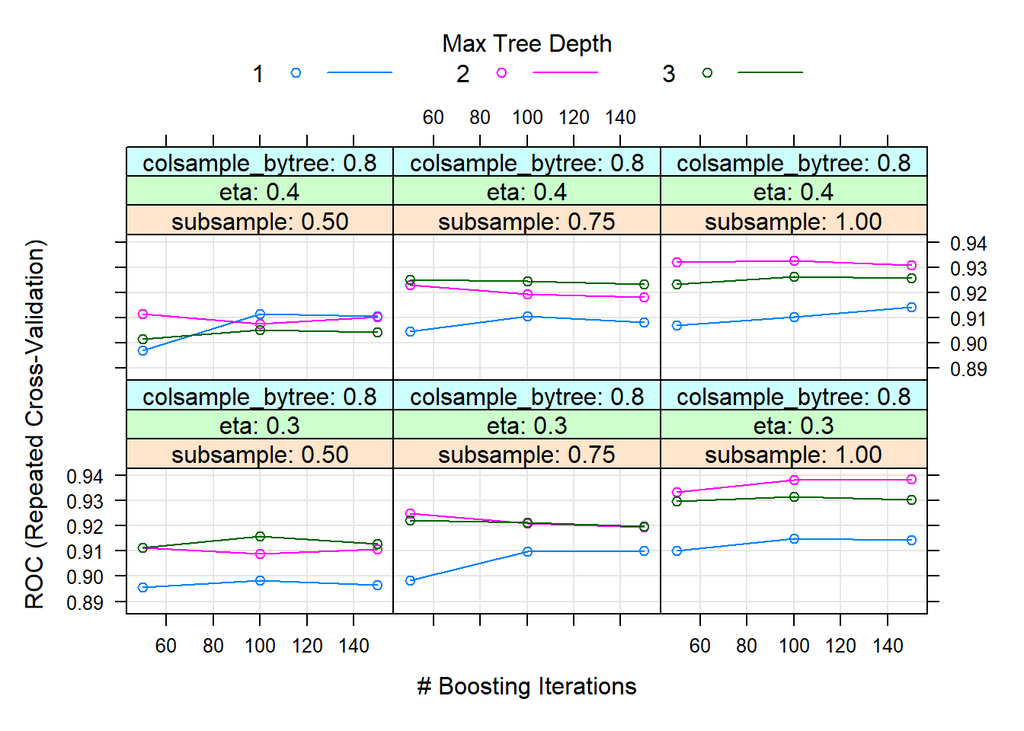

```r
plot(fit_xgb_sonar)
```

### 4c)

**Use the `caret` variable importance method and plot the top 20 variable importances for the random forest model and the XGBoost model.**

**Are the top 4 ranked inputs the same as those identified by the neural network?**

#### SOLUTION

Plot the top 20 ranked inputs based on the random forest.

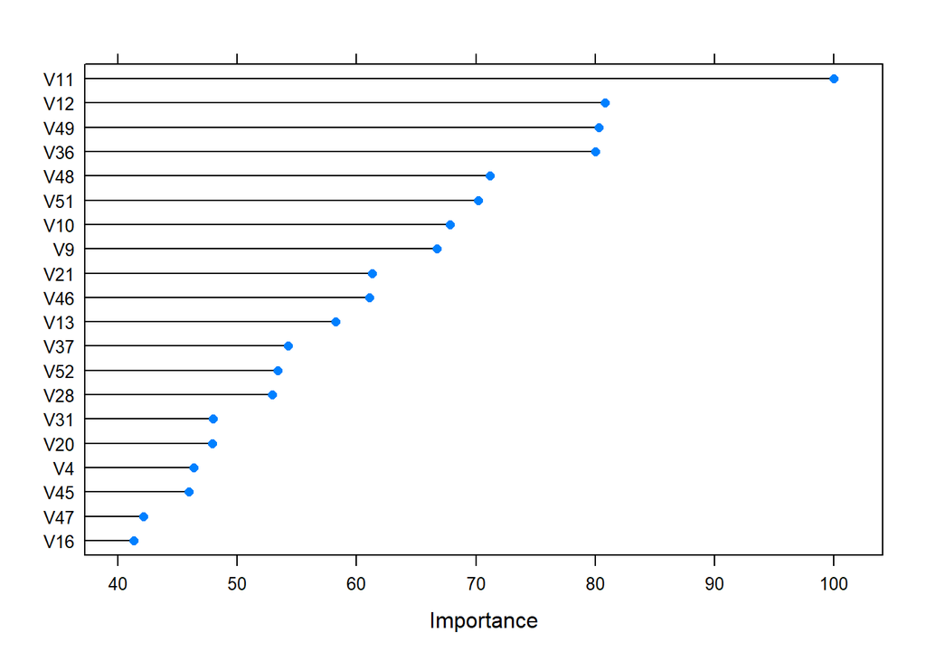

```r
###
plot(varImp(fit_rf_sonar), top = 20)
```

Plot the top 20 ranked inputs based on XGBoost.

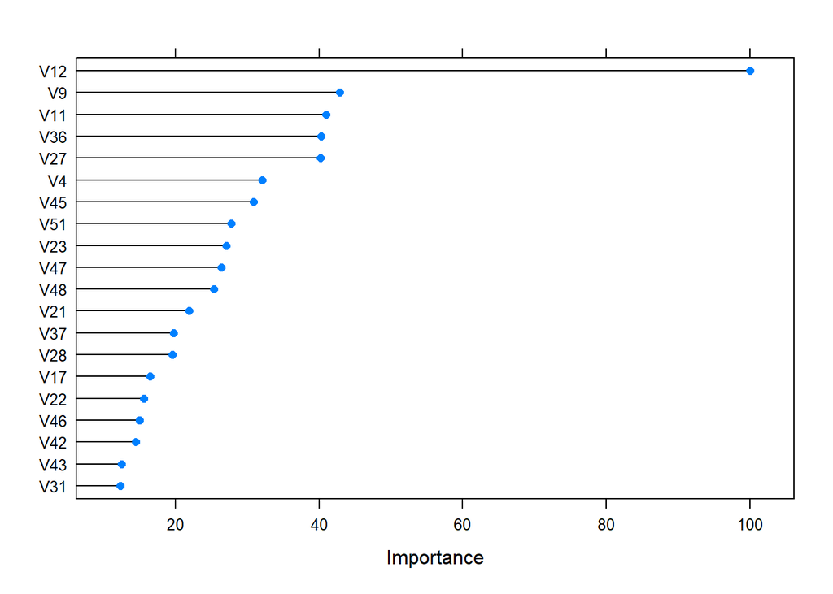

```r
###
plot(varImp(fit_xgb_sonar), top = 20)
```

### 4d)

**Create an input test grid based on the top ranked inputs from the random forest model.**

**Assign the result to the `viz_input_grid_rf` object.**

#### SOLUTION

```r
top_4_inputs <- c("V11", "V12", "V49", "V36")
variable_names <- names(Sonar)
variable_names <- variable_names[1:60]
viz_input_grid_rf <- make_test_input_grid(variable_names, top_4_inputs, Sonar)
```

### 4e)

**Predict the class probabilities with the random forest model for the original neural network based input grid and the new random forest ranked input grid.**

**Assign the predicted probabilities based on the neural network input grid to `pred_prob_rf_on_nnet_grid`. Assign the predicted probabilities based on the random forest input grid to `pred_prob_rf_on_rf_grid`.**

#### SOLUTION

Random forest predictions on the neural network based input grid.

```r
pred_prob_rf_on_nnet_grid <- predict(fit_rf_sonar , viz_input_grid, type = 'prob')
```

Random forest predictions on the random forest based input grid.

```r
pred_prob_rf_on_rf_grid <- predict(fit_rf_sonar, viz_input_grid_rf, type = 'prob')
```

### 4f)

**Visualize the predicted probability surfaces for the `M` class using the same visualization approach used in Problem 3f).**

#### SOLUTION

Visualize the predicted probability surface based on the neural network grid.

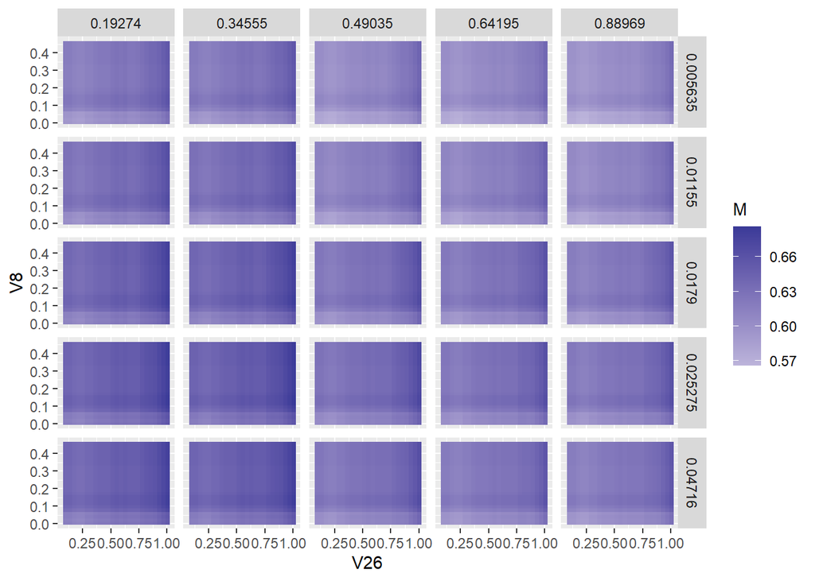

```r
bind_cols(pred_prob_rf_on_nnet_grid, viz_input_grid) %>%
  ggplot(aes(x = V26, y = V8)) +
  geom_raster(aes(fill = M)) +
  facet_grid(V50 ~ V31) +
  scale_fill_gradient2(mid = 'white', midpoint = 0.5)
```

Visualize the predicted probability surface based on the random forest grid.

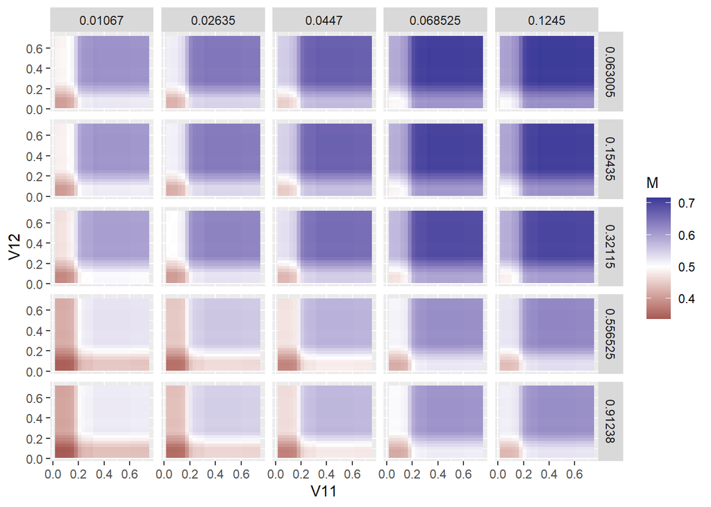

```r
###
bind_cols(pred_prob_rf_on_rf_grid, viz_input_grid_rf) %>%
  ggplot(aes(x = V11, y = V12)) +
  geom_raster(aes(fill = M)) +
  facet_grid(V36 ~ V49) +
  scale_fill_gradient2(mid = 'white', midpoint = 0.5)
```

## Problem 05

Now that you have trained and tuned multiple models of varying complexity, it’s time to identify the best performing model.

### 5a)

The resampling results are compiled together using the `resamples()` function. You must complete the first code chunk below by assigning the model object to the corresponding name in the list. For example, you must set the `fit_glm_sonar` object to the `GLM` variable in the list.

**Complete the first code chunk below, by assigning the `caret` trained model objects to their appropriate variables in the list.**

**The results are then plotted for you using `dotplot()` which model is the best?**

#### SOLUTION

Based on the visualizations, the best model is the random forest because it has high ROC, sensitivity.

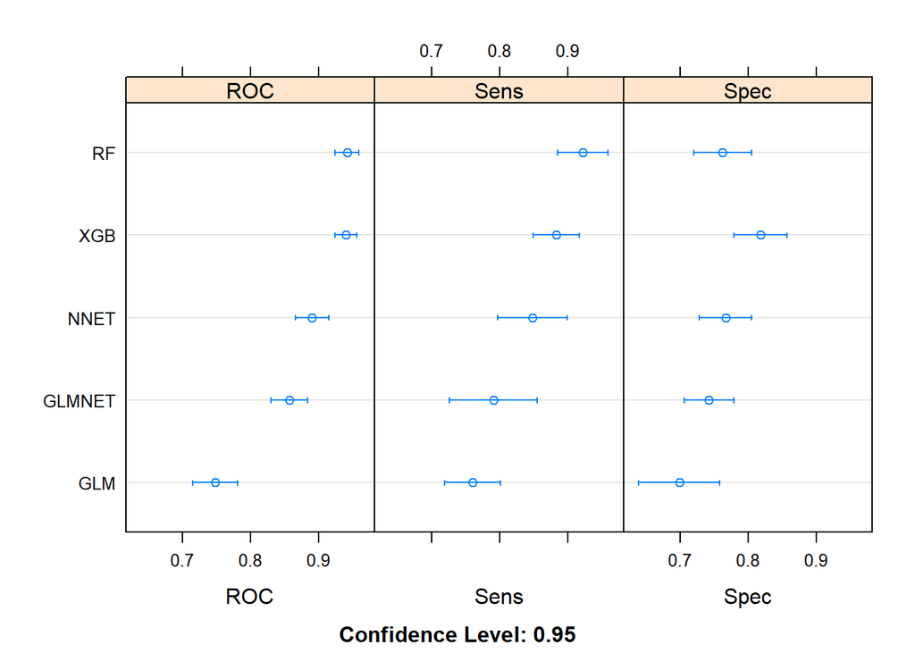

```r
sonar_roc_compare <- resamples(list(GLM = fit_glm_sonar,
                                    GLMNET = fit_glmnet_sonar,
                                    NNET = fit_nnet_sonar,
                                    RF = fit_rf_sonar,
                                    XGB = fit_xgb_sonar))

dotplot(sonar_roc_compare)
```

### 5b)

The code chunk below is completed for you. It extracts the hold-out set predictions associated with the best tuning parameter values for 4 of the models you trained, the logistic regression model, the elastic net, the neural network, and the random forest.

```r
model_pred_results <- fit_rf_sonar$pred %>% tibble::as_tibble() %>%
  filter(mtry == fit_rf_sonar$bestTune$mtry) %>%
  select(pred, obs, M, R, rowIndex, Resample) %>%
  mutate(model_name = "RF") %>%
  bind_rows(fit_glm_sonar$pred %>% tibble::as_tibble() %>%
  select(pred, obs, M, R, rowIndex, Resample) %>%
  mutate(model_name = "GLM")) %>%
  bind_rows(fit_glmnet_sonar$pred %>% tibble::as_tibble() %>%
              filter(alpha == fit_glmnet_sonar$bestTune$alpha,
                     lambda == fit_glmnet_sonar$bestTune$lambda) %>%
              select(pred, obs, M, R, rowIndex, Resample) %>%
              mutate(model_name = "GLMNET")) %>%
  bind_rows(fit_nnet_sonar$pred %>% tibble::as_tibble() %>%
              filter(size == fit_nnet_sonar$bestTune$size,
                     decay == fit_nnet_sonar$bestTune$decay) %>%
              select(pred, obs, M, R, rowIndex, Resample) %>%
              mutate(model_name = "NNET"))
```

The first few rows of the `model_pred_results` object are displayed for you in the code chunk below.

```r
model_pred_results %>% head()
```

```
## # A tibble: 6 x 7
##   pred  obs       M     R rowIndex Resample   model_name
##   <fct> <fct> <dbl> <dbl>    <int> <chr>      <chr>
## 1 M     R     0.624 0.376        3 Fold1.Rep1 RF
## 2 R     R     0.494 0.506        5 Fold1.Rep1 RF
## 3 R     R     0.294 0.706       10 Fold1.Rep1 RF
## 4 R     R     0.104 0.896       11 Fold1.Rep1 RF
## 5 R     R     0.498 0.502       16 Fold1.Rep1 RF
## 6 M     R     0.63  0.37        20 Fold1.Rep1 RF
```

You must use the `model_pred_results` to plot the ROC curves associated with the best tuning parameter results. You will use the `roc_curve()` function from the `yardstick` package to create the ROC curve, just as you did in an earlier assignment. You should have `yardstick` installed already. If you do not please download and install `yardstick` before running the code chunk below.

```r
library(yardstick)
```

**Create the cross-validation averaged ROC curve for each of the models you trained. To do so, pipe the `model_pred_results` objects into `group_by()` and specify the grouping variable as `model_name`. Pipe the result to `roc_curve()` function with `obs` as the first argument and `M` as the second argument. Pipe the result to the `autoplot()` function.**

**Are your generated ROC curves in aggreement with your cross-validation summary stats displayed before?**

#### SOLUTION

Yes, the ROC curves agree with previous cross-validation summary statistics for the models.

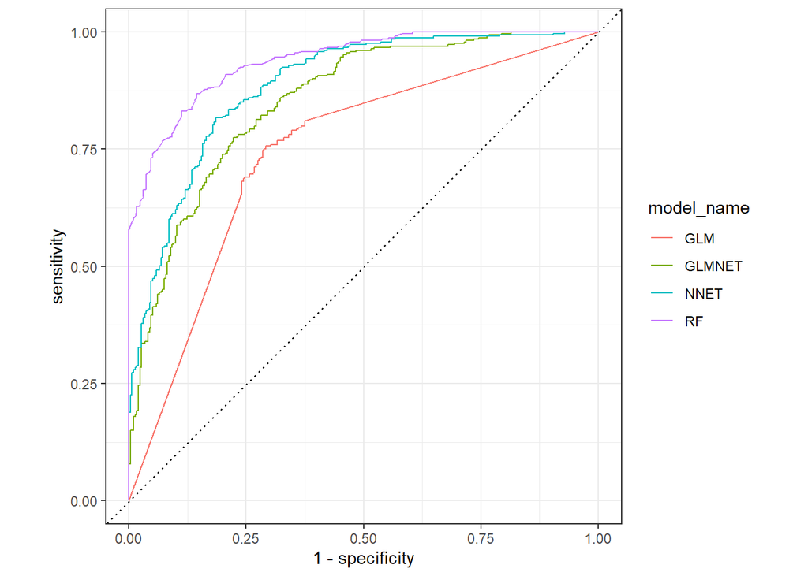

```r
###
model_pred_results %>% group_by(model_name) %>% roc_curve(obs, M) %>% autoplot()
```

### 5c)

It can be useful to get a sense of the variability in the ROC curve, based on the variation in performance across resample folds. You will use the `roc_curve()` function again, but this time you cannot use `autoplot()` to create the ROC curve. You will need to use the `geom_path()` function from ggplot2, to create the figure manually.

**Pipe the `model_pred_results` object to `group_by()` and specify the grouping variables to be `model_name` and `Resample`. Pipe the result to `roc_curve()` with the first argument assigned as `obs` and the second argument assigned as `M`. Pipe the result to `ggplot()` where you map the `x` aesthetic to `1 - specificity` and the `y` aesthetic to `sensitivity`. Add in the `geom_path()` layer where you map the group `color` aesthetic to `Resample`. Use the `facet_wrap()` function to create separate facets for the models that you trained. However, before your `facet_wrap()` function include `geom_abline()` with `slope = 1` and `intercept = 0` and `linetype = 'dotted'`. Also include the `coord_equal()` function. The line and equal coordinates will help make the ROC curve graphic easier to read.**

#### SOLUTION

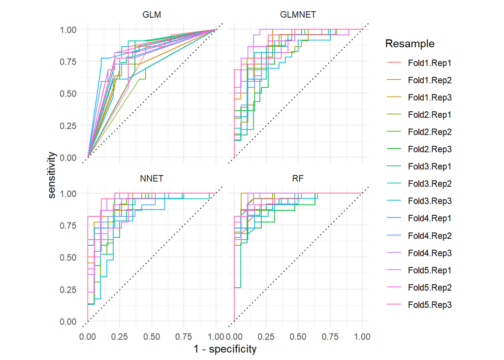

```r
model_pred_results %>%
  group_by(model_name, Resample) %>%
  roc_curve(obs, M) %>%
  ggplot(mapping = aes(x = 1 - specificity, y = sensitivity)) +
  geom_path(mapping = aes(color = Resample)) +
  geom_abline(slope = 1, intercept = 0, linetype = 'dotted') +
  facet_wrap(~model_name) +
  coord_equal() +
  theme_minimal()
```